# Financial_Analysis_Ticker_META

## Financial Analysis

Hemant Thapa

Date: 13/11/2022

This is an open-research conducted on Meta (Facebook), All material used during research are free of cost and open-source softwares, such as Jupyter Notebook, Pandas, Numpy, Seaborn, Matplotlib, Python in-built libraries and yahoo finance Api.

[figure not shown]

Meta has cut down, 13 per cent of its workers, which are nearly 11,000 employees.Meta with the headcount of correction, Meta still accquire more staff than it has last year. In the end of December 2021, the company had almost 72,000 staff, on last Wednesday, the cuts shrank its workforce from more than 85,000 to about 74,000.Nearly $89bn has been wiped from the company’s market capitalisation in late October, when Meta has posted declining revenues. Meta shares closed up more than 5 per cent on Wednesday.

#### DS & Algorithms

```
Enter Your Stock Ticker: meta
```

##### ----------------------------------------------------------------------------------------------------------------------------------------------------------------------------------------------------------------

### 1. Techincal Analysis

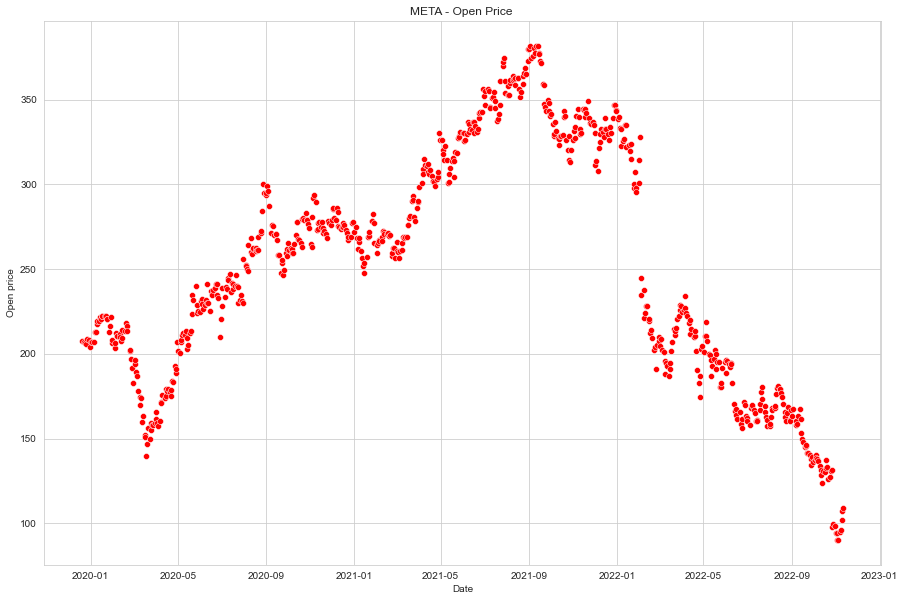

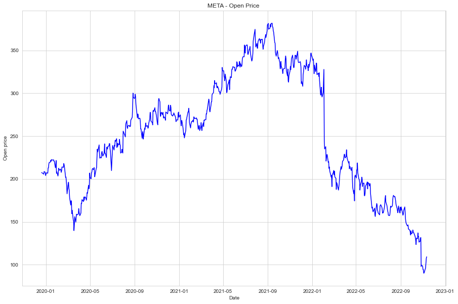

|  | Open | High | Low | Close | Volume | Dividends | Stock Splits |
| --- | --- | --- | --- | --- | --- | --- | --- |
| count | 730.000000 | 730.000000 | 730.000000 | 730.000000 | 7.300000e+02 | 730.0 | 730.0 |
| mean | 250.804096 | 254.538356 | 247.190438 | 250.847863 | 2.521698e+07 | 0.0 | 0.0 |
| std | 68.894437 | 69.103637 | 68.596572 | 68.910614 | 1.744393e+07 | 0.0 | 0.0 |
| min | 90.080002 | 90.459999 | 88.089996 | 88.910004 | 6.046300e+06 | 0.0 | 0.0 |
| 25% | 197.085003 | 202.165001 | 193.154995 | 197.312496 | 1.555728e+07 | 0.0 | 0.0 |
| 50% | 256.764999 | 260.584991 | 251.525002 | 255.065002 | 2.131895e+07 | 0.0 | 0.0 |
| 75% | 312.007492 | 314.719994 | 307.747498 | 312.050003 | 2.948780e+07 | 0.0 | 0.0 |
| max | 381.679993 | 384.329987 | 378.809998 | 382.179993 | 2.323166e+08 | 0.0 | 0.0 |

##### ----------------------------------------------------------------------------------------------------------------------------------------------------------------------------------------------------------------

### 2. Fundamental Analysis

#### 2.1 Income statement - Annual

|  | 2021-12-31 | 2020-12-31 | 2019-12-31 | 2018-12-31 |
| --- | --- | --- | --- | --- |
| Research Development | 24655000000.0 | 18447000000.0 | 13600000000.0 | 10273000000.0 |
| Effect Of Accounting Charges | None | None | None | None |
| Income Before Tax | 47284000000.0 | 33180000000.0 | 24812000000.0 | 25361000000.0 |
| Minority Interest | None | None | None | None |
| Net Income | 39370000000.0 | 29146000000.0 | 18485000000.0 | 22112000000.0 |
| Selling General Administrative | 23872000000.0 | 18155000000.0 | 15341000000.0 | 11297000000.0 |
| Gross Profit | 95280000000.0 | 69273000000.0 | 57927000000.0 | 46483000000.0 |
| Ebit | 46753000000.0 | 32671000000.0 | 28986000000.0 | 24913000000.0 |
| Operating Income | 46753000000.0 | 32671000000.0 | 28986000000.0 | 24913000000.0 |
| Other Operating Expenses | None | None | None | None |
| Interest Expense | None | None | None | None |
| Extraordinary Items | None | None | None | None |
| Non Recurring | None | None | None | None |
| Other Items | None | None | None | None |
| Income Tax Expense | 7914000000.0 | 4034000000.0 | 6327000000.0 | 3249000000.0 |
| Total Revenue | 117929000000.0 | 85965000000.0 | 70697000000.0 | 55838000000.0 |
| Total Operating Expenses | 71176000000.0 | 53294000000.0 | 41711000000.0 | 30925000000.0 |
| Cost Of Revenue | 22649000000.0 | 16692000000.0 | 12770000000.0 | 9355000000.0 |
| Total Other Income Expense Net | 531000000.0 | 509000000.0 | -4174000000.0 | 448000000.0 |
| Discontinued Operations | None | None | None | None |
| Net Income From Continuing Ops | 39370000000.0 | 29146000000.0 | 18485000000.0 | 22112000000.0 |
| Net Income Applicable To Common Shares | 39370000000.0 | 29146000000.0 | 18485000000.0 | 22111000000.0 |

#### Graph 1 - Annual Research and Development Analysis

```
Research and development has been increased
```

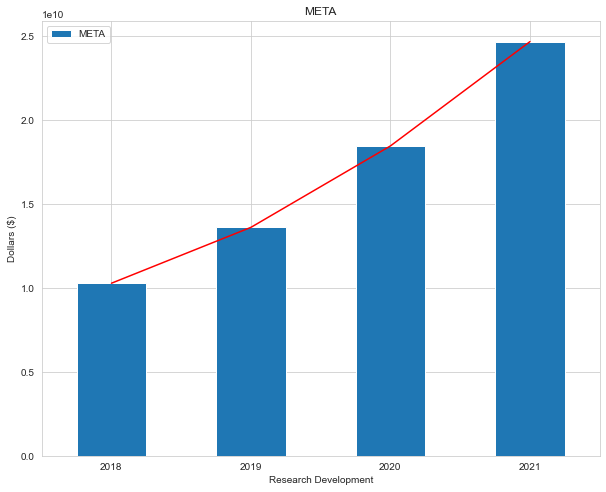

#### Research and development validation

```
R&D 2018: $10273000000.0
R&D 2019: $13600000000.0
R&D 2020: $18447000000.0
R&D 2021: $24655000000.0
```

```
Difference on Annual R&D: $6208000000.0
```

#### Graph 2 - Annual Revenue

```
Revenue has been increases $31964000000.0
```

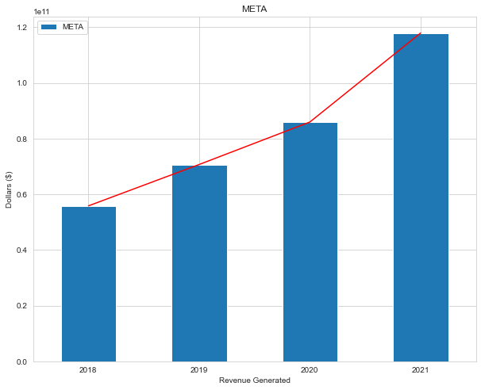

#### Revenue validation

```
Revenue 2018: 55838000000.0
Revenue 2019: 70697000000.0
Revenue 2020: 85965000000.0
Revenue 2021: 117929000000.0
```

```
Difference in Annual Revenue: $31964000000.0
```

#### Income statement Quarterly

|  | 2022-09-30 | 2022-06-30 | 2022-03-31 | 2021-12-31 |
| --- | --- | --- | --- | --- |
| Research Development | 8939000000.0 | 8690000000.0 | 7707000000.0 | 7046000000.0 |
| Effect Of Accounting Charges | None | None | None | None |
| Income Before Tax | 5576000000.0 | 8186000000.0 | 8908000000.0 | 12703000000.0 |
| Minority Interest | None | None | None | None |
| Net Income | 4395000000.0 | 6687000000.0 | 7465000000.0 | 10285000000.0 |
| Selling General Administrative | 7015000000.0 | 6582000000.0 | 5672000000.0 | 7692000000.0 |
| Gross Profit | 22031000000.0 | 23630000000.0 | 21903000000.0 | 27323000000.0 |
| Ebit | 6077000000.0 | 8358000000.0 | 8524000000.0 | 12585000000.0 |
| Operating Income | 6077000000.0 | 8358000000.0 | 8524000000.0 | 12585000000.0 |
| Other Operating Expenses | None | None | None | None |
| Interest Expense | None | None | None | None |
| Extraordinary Items | None | None | None | None |
| Non Recurring | None | None | None | None |
| Other Items | None | None | None | None |
| Income Tax Expense | 1181000000.0 | 1499000000.0 | 1443000000.0 | 2418000000.0 |
| Total Revenue | 27714000000.0 | 28822000000.0 | 27908000000.0 | 33671000000.0 |
| Total Operating Expenses | 21637000000.0 | 20464000000.0 | 19384000000.0 | 21086000000.0 |
| Cost Of Revenue | 5683000000.0 | 5192000000.0 | 6005000000.0 | 6348000000.0 |
| Total Other Income Expense Net | -501000000.0 | -172000000.0 | 384000000.0 | 118000000.0 |
| Discontinued Operations | None | None | None | None |
| Net Income From Continuing Ops | 4395000000.0 | 6687000000.0 | 7465000000.0 | 10285000000.0 |
| Net Income Applicable To Common Shares | 4395000000.0 | 6687000000.0 | 7465000000.0 | 10285000000.0 |

#### 2.2 Balance Sheet - Annual

|  | 2021-12-31 | 2020-12-31 | 2019-12-31 | 2018-12-31 |
| --- | --- | --- | --- | --- |
| Intangible Assets | 6.340000e+08 | 6.230000e+08 | 8.940000e+08 | 1.294000e+09 |
| Capital Surplus | 5.581100e+10 | 5.001800e+10 | 4.585100e+10 | 4.290600e+10 |
| Total Liab | 4.110800e+10 | 3.102600e+10 | 3.232200e+10 | 1.320700e+10 |
| Total Stockholder Equity | 1.248790e+11 | 1.282900e+11 | 1.010540e+11 | 8.412700e+10 |
| Other Current Liab | 1.269800e+10 | 1.001800e+10 | 1.118600e+10 | 4.494000e+09 |
| Total Assets | 1.659870e+11 | 1.593160e+11 | 1.333760e+11 | 9.733400e+10 |
| Other Current Assets | 1.490000e+08 | 2.410000e+08 | 8.000000e+06 | 1.000000e+07 |
| Retained Earnings | 6.976100e+10 | 7.734500e+10 | 5.569200e+10 | 4.198100e+10 |
| Other Liab | 6.721000e+09 | 6.414000e+09 | 7.745000e+09 | 6.190000e+09 |
| Good Will | 1.919700e+10 | 1.905000e+10 | 1.871500e+10 | 1.830100e+10 |
| Gains Losses Not Affecting Retained Earnings | -6.930000e+08 | 9.270000e+08 | -4.890000e+08 | -7.600000e+08 |
| Other Assets | 2.751000e+09 | 2.758000e+09 | 2.673000e+09 | 2.576000e+09 |
| Cash | 1.660100e+10 | 1.757600e+10 | 1.907900e+10 | 1.001900e+10 |
| Total Current Liabilities | 2.113500e+10 | 1.498100e+10 | 1.505300e+10 | 7.017000e+09 |
| Other Stockholder Equity | -6.930000e+08 | 9.270000e+08 | -4.890000e+08 | -7.600000e+08 |
| Property Plant Equipment | 6.996400e+10 | 5.498100e+10 | 4.478300e+10 | 2.468300e+10 |
| Total Current Assets | 6.666600e+10 | 7.567000e+10 | 6.622500e+10 | 5.048000e+10 |
| Long Term Investments | 6.775000e+09 | 6.234000e+09 | 8.600000e+07 | NaN |
| Net Tangible Assets | 1.050480e+11 | 1.086170e+11 | 8.144500e+10 | 6.453200e+10 |
| Short Term Investments | 3.139700e+10 | 4.437800e+10 | 3.577600e+10 | 3.109500e+10 |
| Net Receivables | 1.403900e+10 | 1.133500e+10 | 9.518000e+09 | 7.587000e+09 |
| Accounts Payable | 4.083000e+09 | 1.331000e+09 | 1.363000e+09 | 8.200000e+08 |
| Common Stock | NaN | NaN | NaN | 4.290600e+10 |

#### Graph 3 - Total Assets Analysis

```
Assets has been increases $6671000000.0
```

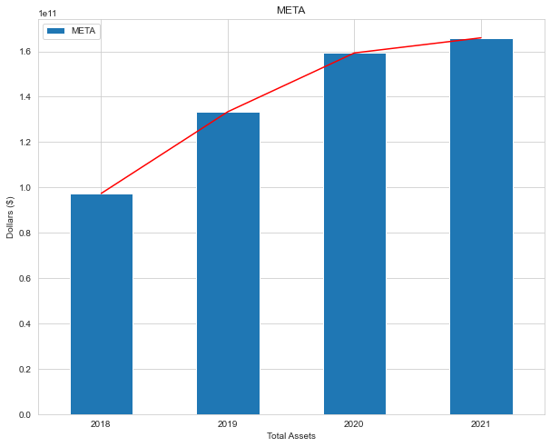

#### Total Assets Validation

```
Assets 2018: $97334000000.0
Assets 2019: $133376000000.0
Assets 2020: $159316000000.0
Assets 2021: $165987000000.0
```

```
Difference in Total assets: $6671000000.0
```

#### Graph 4 - Total Liabilities

```
Liabilities has been increases $10082000000.0
```

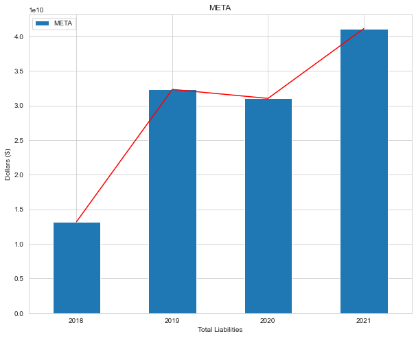

#### Total Liabilities Validation

```
Liabilities 2018: $13207000000.0
Liabilities 2019: $32322000000.0
Liabilities 2020: $31026000000.0
Liabilities 2021: $41108000000.0
```

```
Difference in Total Liabilities: $10082000000.0
```

#### Balance Sheet Quarterly

|  | 2022-09-30 | 2022-06-30 | 2022-03-31 | 2021-12-31 |
| --- | --- | --- | --- | --- |
| Intangible Assets | 8.750000e+08 | 9.650000e+08 | 9.100000e+08 | 6.340000e+08 |
| Capital Surplus | 6.209200e+10 | 5.992900e+10 | 5.751200e+10 | 5.581100e+10 |
| Total Liab | 5.480000e+10 | 4.401200e+10 | 4.099000e+10 | 4.110800e+10 |
| Total Stockholder Equity | 1.240940e+11 | 1.257670e+11 | 1.232280e+11 | 1.248790e+11 |
| Other Current Liab | 1.489000e+09 | 1.514000e+09 | 1.455000e+09 | 1.269800e+10 |
| Total Assets | 1.788940e+11 | 1.697790e+11 | 1.642180e+11 | 1.659870e+11 |
| Other Current Assets | 2.320000e+08 | 2.280000e+08 | 2.940000e+08 | 1.490000e+08 |
| Retained Earnings | 6.705600e+10 | 6.924900e+10 | 6.771200e+10 | 6.976100e+10 |
| Other Liab | 6.987000e+09 | 6.469000e+09 | 6.486000e+09 | 6.721000e+09 |
| Good Will | 2.026800e+10 | 2.022900e+10 | 1.992300e+10 | 1.919700e+10 |
| Gains Losses Not Affecting Retained Earnings | -5.054000e+09 | -3.411000e+09 | -1.996000e+09 | -6.930000e+08 |
| Other Assets | 5.529000e+09 | 4.344000e+09 | 3.522000e+09 | 2.751000e+09 |
| Cash | 1.430800e+10 | 1.268100e+10 | 1.488600e+10 | 1.660100e+10 |
| Total Current Liabilities | 2.268700e+10 | 2.221700e+10 | 2.108600e+10 | 2.113500e+10 |
| Other Stockholder Equity | -5.054000e+09 | -3.411000e+09 | -1.996000e+09 | -6.930000e+08 |
| Property Plant Equipment | 8.737900e+10 | 8.171800e+10 | 7.382300e+10 | 6.996400e+10 |
| Total Current Assets | 5.831500e+10 | 5.598700e+10 | 5.926500e+10 | 6.666600e+10 |
| Long Term Investments | 6.528000e+09 | 6.536000e+09 | 6.775000e+09 | 6.775000e+09 |
| Net Tangible Assets | 1.029510e+11 | 1.045730e+11 | 1.023950e+11 | 1.050480e+11 |
| Short Term Investments | 2.746800e+10 | 2.780800e+10 | 2.900400e+10 | 3.139700e+10 |
| Net Receivables | 1.122700e+10 | 1.152500e+10 | 1.139000e+10 | 1.403900e+10 |
| Long Term Debt | 9.922000e+09 | NaN | NaN | NaN |
| Accounts Payable | 3.871000e+09 | 4.008000e+09 | 3.246000e+09 | 4.083000e+09 |

#### 2.3 Cashflow Annual

|  | 2021-12-31 | 2020-12-31 | 2019-12-31 | 2018-12-31 |
| --- | --- | --- | --- | --- |
| Investments | 1.213200e+10 | -1.452000e+10 | -4.254000e+09 | 2.449000e+09 |
| Change To Liabilities | 1.623000e+09 | 9.100000e+07 | 2.360000e+08 | 2.740000e+08 |
| Total Cashflows From Investing Activities | -7.570000e+09 | -3.005900e+10 | -1.986400e+10 | -1.160300e+10 |
| Net Borrowings | -6.630000e+08 | -5.800000e+08 | -7.750000e+08 | 5.000000e+08 |
| Total Cash From Financing Activities | -5.072800e+10 | -1.029200e+10 | -7.299000e+09 | -1.557200e+10 |
| Change To Operating Activities | 2.187000e+09 | -1.302000e+09 | 8.975000e+09 | 9.100000e+07 |
| Net Income | 3.937000e+10 | 2.914600e+10 | 1.848500e+10 | 2.211200e+10 |
| Change In Cash | -1.089000e+09 | -1.325000e+09 | 9.155000e+09 | 1.920000e+09 |
| Repurchase Of Stock | -5.005200e+10 | -9.836000e+09 | -6.539000e+09 | -1.608700e+10 |
| Effect Of Exchange Rate | -4.740000e+08 | 2.790000e+08 | 4.000000e+06 | -1.790000e+08 |
| Total Cash From Operating Activities | 5.768300e+10 | 3.874700e+10 | 3.631400e+10 | 2.927400e+10 |
| Depreciation | 7.967000e+09 | 6.862000e+09 | 5.741000e+09 | 4.315000e+09 |
| Other Cashflows From Investing Activities | -2.840000e+08 | -3.600000e+07 | -3.600000e+07 | -3.600000e+07 |
| Change To Account Receivables | -3.110000e+09 | -1.512000e+09 | -1.961000e+09 | -1.892000e+09 |
| Other Cashflows From Financing Activities | -1.300000e+07 | 1.240000e+08 | 1.500000e+07 | 1.500000e+07 |
| Change To Netincome | 9.646000e+09 | 5.462000e+09 | 4.838000e+09 | 4.374000e+09 |
| Capital Expenditures | -1.856700e+10 | -1.511500e+10 | -1.510200e+10 | -1.391500e+10 |

#### Cashflow Quarterly

|  | 2022-09-30 | 2022-06-30 | 2022-03-31 | 2021-12-31 |
| --- | --- | --- | --- | --- |
| Investments | -3.280000e+08 | 9.390000e+08 | 1.399000e+09 | 1.184300e+10 |
| Change To Liabilities | -2.800000e+07 | 2.610000e+08 | -9.340000e+08 | 9.760000e+08 |
| Total Cashflows From Investing Activities | -9.701000e+09 | -6.959000e+09 | -4.779000e+09 | 5.829000e+09 |
| Net Borrowings | 9.567000e+09 | -2.980000e+08 | -2.130000e+08 | -1.730000e+08 |
| Total Cash From Financing Activities | 2.147000e+09 | -6.563000e+09 | -1.066000e+10 | -2.174200e+10 |
| Change To Operating Activities | 7.010000e+08 | 7.040000e+08 | 1.118000e+09 | 3.678000e+09 |
| Net Income | 4.395000e+09 | 6.687000e+09 | 7.465000e+09 | 1.028500e+10 |
| Change In Cash | 1.773000e+09 | -1.875000e+09 | -1.512000e+09 | 2.061000e+09 |
| Repurchase Of Stock | -7.365000e+09 | -6.235000e+09 | -1.043100e+10 | -2.156900e+10 |
| Effect Of Exchange Rate | -3.650000e+08 | -5.490000e+08 | -1.490000e+08 | -1.300000e+08 |
| Total Cash From Operating Activities | 9.692000e+09 | 1.219600e+10 | 1.407600e+10 | 1.810400e+10 |
| Depreciation | 2.175000e+09 | 1.979000e+09 | 2.156000e+09 | 2.014000e+09 |
| Other Cashflows From Investing Activities | 1.600000e+07 | -7.000000e+06 | -1.000000e+07 | -1.240000e+08 |
| Change To Account Receivables | -1.050000e+08 | -5.220000e+08 | 2.557000e+09 | -2.038000e+09 |
| Other Cashflows From Financing Activities | -5.500000e+07 | -3.000000e+07 | -1.600000e+07 | -1.600000e+07 |
| Change To Netincome | 2.554000e+09 | 3.087000e+09 | 1.714000e+09 | 3.189000e+09 |
| Capital Expenditures | -9.375000e+09 | -7.572000e+09 | -5.441000e+09 | -5.369000e+09 |

##### ----------------------------------------------------------------------------------------------------------------------------------------------------------------------------------------------------------------

#### 2.4 Stock Recommendations

```
                                   Firm           To Grade      From Grade  \
Date
2022-01-19 14:03:49      Morgan Stanley         Overweight
2022-01-26 11:51:52         RBC Capital         Outperform
2022-02-03 09:37:12             Keybanc         Overweight
2022-02-03 10:23:02       Raymond James         Outperform      Strong Buy
2022-02-03 10:24:52         BMO Capital     Market Perform      Outperform
2022-02-03 11:37:44              Mizuho                Buy
2022-02-03 11:43:59      JMP Securities  Market Outperform
2022-02-03 11:47:37            Barclays         Overweight
2022-02-03 11:48:38       Goldman Sachs                Buy
2022-02-03 11:50:09       Piper Sandler            Neutral
2022-02-03 11:51:15   Truist Securities                Buy
2022-02-03 11:54:29                 UBS                Buy
2022-02-03 12:23:12           JP Morgan            Neutral      Overweight
2022-02-03 12:57:53      Morgan Stanley         Overweight
2022-02-03 14:05:37       Credit Suisse         Outperform
2022-02-03 15:27:28        Loop Capital               Hold             Buy
2022-02-04 10:47:04             DZ Bank               Sell            Hold
2022-02-04 11:41:16   China Renaissance               Hold             Buy
2022-02-04 12:34:01          Rosenblatt                Buy
2022-02-04 14:00:28      Argus Research               Hold             Buy
2022-02-08 13:54:05      KGI Securities            Neutral      Outperform
2022-03-01 12:46:24           Benchmark               Hold
2022-03-02 14:30:48      Morgan Stanley         Overweight
2022-03-08 13:58:26       Piper Sandler            Neutral
2022-03-11 10:10:54       Deutsche Bank                Buy
2022-04-05 13:09:08                 UBS                Buy
2022-04-13 10:45:39         RBC Capital         Outperform
2022-04-19 12:40:55          Rosenblatt            Neutral
2022-04-19 13:12:10      JMP Securities  Market Outperform
2022-04-20 09:05:05           Citigroup                Buy         Neutral
2022-04-21 11:12:48       Credit Suisse         Outperform
2022-04-25 11:42:46              Mizuho                Buy
2022-04-28 10:16:36       Piper Sandler            Neutral
2022-04-28 11:16:44      Morgan Stanley         Overweight
2022-04-28 11:19:43       Raymond James         Outperform
2022-04-28 11:22:44         Susquehanna           Positive
2022-04-28 11:46:18         BMO Capital     Market Perform
2022-04-28 12:07:30   Truist Securities                Buy
```

[output cut: 212 more lines]

```
2022-10-27 11:18:28   main
2022-10-27 11:20:58   main
2022-10-27 11:24:12   main
2022-10-27 13:42:52   main
2022-10-27 13:46:35   main
2022-10-27 13:48:44   main
2022-10-27 13:54:05   main
2022-10-27 13:57:35   main
2022-10-27 14:01:10   main
2022-10-27 14:03:55   main
2022-10-27 14:32:00   main
2022-10-28 10:18:40   down
2022-11-02 17:24:42   main
2022-11-07 11:17:39     up
2022-11-10 12:07:25   main
```

#### 2.5 Institutional Holders

|  | Holder | Shares | Date Reported | % Out | Value |
| --- | --- | --- | --- | --- | --- |
| 0 | Vanguard Group, Inc. (The) | 180403765 | 2022-06-29 | 0.0802 | 20389232914 |
| 1 | Blackrock Inc. | 151566495 | 2022-06-29 | 0.0674 | 17130044756 |
| 2 | FMR, LLC | 115273519 | 2022-09-29 | 0.0513 | 13028212730 |
| 3 | State Street Corporation | 89882589 | 2022-06-29 | 0.0400 | 10158529907 |
| 4 | Price (T.Rowe) Associates Inc | 51634675 | 2022-06-29 | 0.0230 | 5835750795 |
| 5 | Capital International Investors | 49532448 | 2022-06-29 | 0.0220 | 5598157106 |
| 6 | Geode Capital Management, LLC | 42657115 | 2022-06-29 | 0.0190 | 4821106994 |
| 7 | Capital World Investors | 38385031 | 2022-06-29 | 0.0171 | 4338276074 |
| 8 | Morgan Stanley | 31958517 | 2022-06-29 | 0.0142 | 3611951484 |
| 9 | Capital Research Global Investors | 31073962 | 2022-06-29 | 0.0138 | 3511979080 |

|  | holders | Shares |
| --- | --- | --- |
| 0 | Vanguard Group, Inc. (The) | 180403765 |
| 1 | Blackrock Inc. | 151566495 |
| 2 | FMR, LLC | 115273519 |
| 3 | State Street Corporation | 89882589 |
| 4 | Price (T.Rowe) Associates Inc | 51634675 |
| 5 | Capital International Investors | 49532448 |
| 6 | Geode Capital Management, LLC | 42657115 |
| 7 | Capital World Investors | 38385031 |
| 8 | Morgan Stanley | 31958517 |
| 9 | Capital Research Global Investors | 31073962 |

#### Institutional Holders - pie chart

```
[Text(0, 0.5, '')]
```

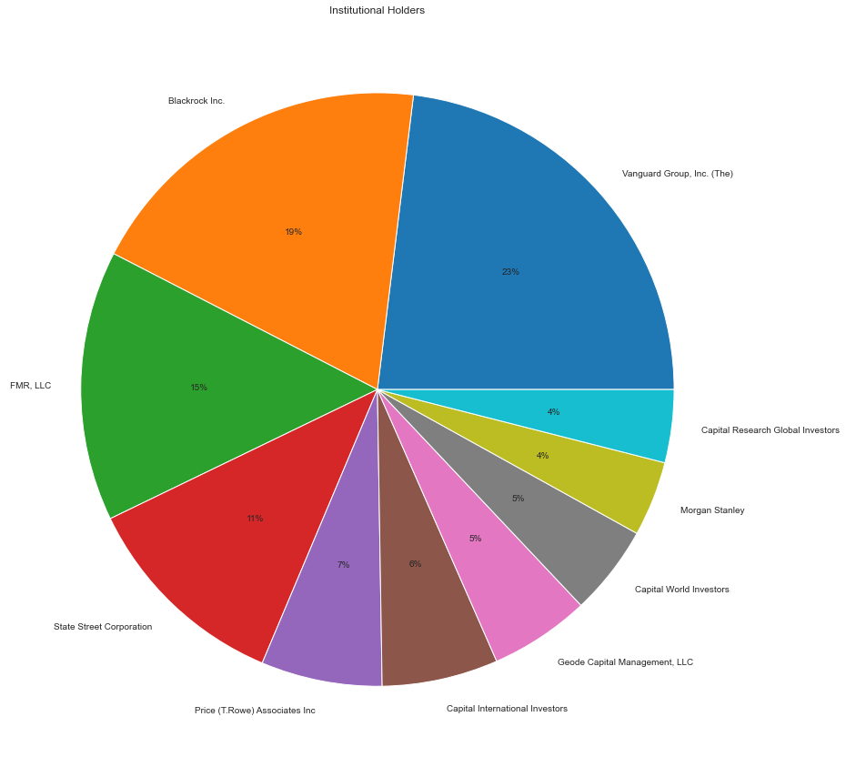

#### 2.6 Major Holders

|  | Percentage | Major_holder |
| --- | --- | --- |
| 0 | 0.55% | % of Shares Held by All Insider |
| 1 | 75.80% | % of Shares Held by Institutions |
| 2 | 76.22% | % of Float Held by Institutions |
| 3 | 3935 | Number of Institutions Holding Shares |

#### 2.7 Earnings Annual

| Year | Revenue | Earnings |
| --- | --- | --- |
| 2018 | 55838000000 | 22112000000 |
| 2019 | 70697000000 | 18485000000 |
| 2020 | 85965000000 | 29146000000 |
| 2021 | 117929000000 | 39370000000 |

#### Graph 5 - Annual Earning

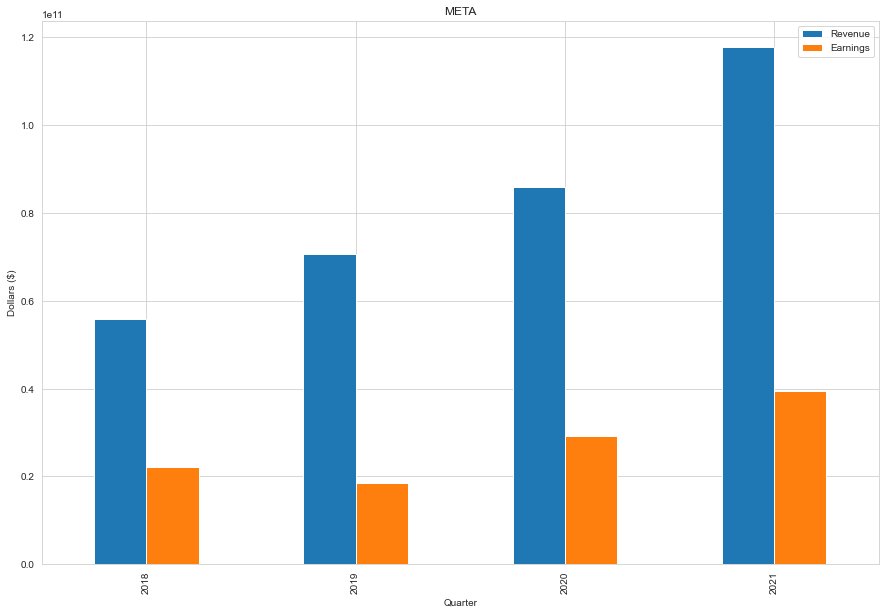

#### 2.8 Earnings Quarterly

| Quarter | Revenue | Earnings |
| --- | --- | --- |
| 4Q2021 | 33671000000 | 10285000000 |
| 1Q2022 | 27908000000 | 7465000000 |
| 2Q2022 | 28822000000 | 6687000000 |
| 3Q2022 | 27714000000 | 4395000000 |

#### Graph 6 - Quarterly Earning

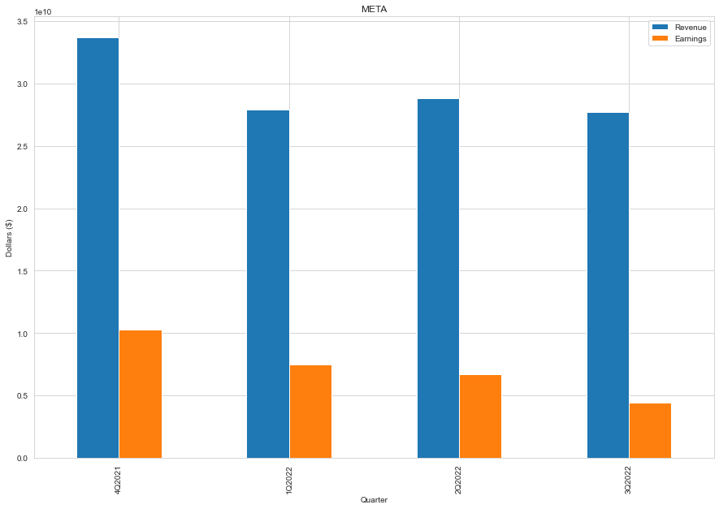

#### 2.9 Actions

|  | Dividends | Stock Splits |
| --- | --- | --- |
| Date |  |  |

#### 2.10 Splits

|  | Stock Splits |
| --- | --- |
| Date |  |

#### 2.11 Dividends

|  | Dividends |
| --- | --- |
| Date |  |

#### 2.12 Options

|  | 0 |
| --- | --- |
| 0 | 2022-11-18 |
| 1 | 2022-11-25 |
| 2 | 2022-12-02 |
| 3 | 2022-12-09 |
| 4 | 2022-12-16 |
| 5 | 2022-12-23 |
| 6 | 2023-01-20 |
| 7 | 2023-02-17 |
| 8 | 2023-03-17 |
| 9 | 2023-06-16 |
| 10 | 2023-09-15 |
| 11 | 2024-01-19 |
| 12 | 2024-06-21 |
| 13 | 2025-01-17 |

#### 2.13 Sustainability

| 2022-8 | Value |
| --- | --- |
| palmOil | False |
| controversialWeapons | False |
| gambling | False |
| socialScore | 21.01 |
| nuclear | False |
| furLeather | False |
| alcoholic | False |
| gmo | False |
| catholic | False |
| socialPercentile | None |
| peerCount | 105 |
| governanceScore | 10.51 |
| environmentPercentile | None |
| animalTesting | False |
| tobacco | False |
| totalEsg | 32.54 |
| highestControversy | 4 |
| esgPerformance | OUT_PERF |
| coal | False |
| pesticides | False |
| adult | False |
| percentile | 71.77 |
| peerGroup | Software & Services |
| smallArms | False |
| environmentScore | 1.02 |
| governancePercentile | None |
| militaryContract | False |

#### 2.14 Calendar

|  | 0 | 1 |
| --- | --- | --- |
| Earnings Date | 2023-01-31 10:59:00 | 2023-02-06 12:00:00 |
| Earnings Average | 2.26 | 2.26 |
| Earnings Low | 1.41 | 1.41 |
| Earnings High | 3.34 | 3.34 |
| Revenue Average | 31518300000 | 31518300000 |
| Revenue Low | 30007600000 | 30007600000 |
| Revenue High | 32434000000 | 32434000000 |

##### ----------------------------------------------------------------------------------------------------------------------------------------------------------------------------------------------------------------

#### 2.15 Comapny Information

```
{'zip': '94025',
 'sector': 'Communication Services',
 'fullTimeEmployees': 87314,
 'longBusinessSummary': "Meta Platforms, Inc. develops products that enable people to connect and share with friends and family through mobile devices, personal computers, virtual reality headsets, wearables, and in-home devices worldwide. It operates in two segments, Family of Apps and Reality Labs…
 'city': 'Menlo Park',
 'phone': '650 543 4800',
 'state': 'CA',
 'country': 'United States',
 'companyOfficers': [],
 'website': 'https://investor.fb.com',
 'maxAge': 1,
 'address1': '1601 Willow Road',
 'industry': 'Internet Content & Information',
 'ebitdaMargins': 0.37138999,
 'profitMargins': 0.2441,
 'grossMargins': 0.80334,
 'operatingCashflow': 54067998720,
 'revenueGrowth': -0.045,
 'operatingMargins': 0.30091998,
 'ebitda': 43867000832,
 'targetLowPrice': 80,
 'recommendationKey': 'buy',
 'grossProfits': 95280000000,
 'freeCashflow': 19749376000,
 'targetMedianPrice': 143,
 'currentPrice': 113.02,
 'earningsGrowth': -0.491,
 'currentRatio': 2.57,
 'returnOnAssets': 0.12749,
 'numberOfAnalystOpinions': 50,
 'targetMeanPrice': 154.89,
 'debtToEquity': 21.339,
 'returnOnEquity': 0.22398001,
 'targetHighPrice': 392,
 'totalCash': 41776001024,
 'totalDebt': 26481000448,
 'totalRevenue': 118115000320,
 'totalCashPerShare': 15.755,
 'financialCurrency': 'USD',
 'revenuePerShare': 43.453,
```

[output cut: 99 more lines]

```
 'volume': 59828022,
 'fiftyTwoWeekHigh': 353.83,
 'fromCurrency': None,
 'fiveYearAvgDividendYield': None,
 'fiftyTwoWeekLow': 88.09,
 'bid': 113.14,
 'tradeable': False,
 'dividendYield': None,
 'bidSize': 800,
 'dayHigh': 114.89,
 'coinMarketCapLink': None,
 'regularMarketPrice': 113.02,
 'preMarketPrice': None,
 'logo_url': 'https://logo.clearbit.com/investor.fb.com',
 'trailingPegRatio': 2.4901}
```

##### ----------------------------------------------------------------------------------------------------------------------------------------------------------------------------------------------------------------

#### 2.16 News

|  | uuid | title | publisher | link | providerPublishTime | type | thumbnail | relatedTickers |
| --- | --- | --- | --- | --- | --- | --- | --- | --- |
| 0 | 7e3bb9fd-4f5e-33bf-a527-08dec648eedd | Meta Platforms Stock Q&A With Wall Street | Motley Fool | https://finance.yahoo.com/m/7e3bb9fd-4f5e-33bf... | 1668256200 | STORY | {'resolutions': [{'url': 'https://s.yimg.com/u... | [META] |
| 1 | 22cb61c9-5a22-39af-934b-a880fcfa2ad1 | There Is A Reason Meta Platforms, Inc.'s (NASD... | Simply Wall St. | https://finance.yahoo.com/news/reason-meta-pla... | 1668250869 | STORY | {'resolutions': [{'url': 'https://s.yimg.com/u... | [META] |
| 2 | 3f6eb657-44f0-3191-bd17-b2f77b7e2f1b | Is The Trade Desk a Good Stock to Buy Now? | Motley Fool | https://finance.yahoo.com/m/3f6eb657-44f0-3191... | 1668249780 | STORY | {'resolutions': [{'url': 'https://s.yimg.com/u... | [TTD, GOOGL, META] |
| 3 | dd7fed01-ae0a-39cb-a0cc-15493ba8c3b5 | Buzly's student-only social media platform exp... | American City Business Journals | https://finance.yahoo.com/m/dd7fed01-ae0a-39cb... | 1668207169 | STORY | {'resolutions': [{'url': 'https://s.yimg.com/u... | [META] |
| 4 | a8f4f277-34f4-3cfa-b1c7-8c38df868e97 | Meta’s massive layoffs and other job cuts spar... | American City Business Journals | https://finance.yahoo.com/m/a8f4f277-34f4-3cfa... | 1668205828 | STORY | {'resolutions': [{'url': 'https://s.yimg.com/u... | [META] |
| 5 | b8daf351-a2b8-329b-b3bb-1a518d2d3b90 | Meta Platforms Is Near a 52-Week Low. Is It a ... | Motley Fool | https://finance.yahoo.com/m/b8daf351-a2b8-329b... | 1668204900 | STORY | {'resolutions': [{'url': 'https://s.yimg.com/u... | [META] |
| 6 | 2c0451ee-eeb0-3730-ba9a-fbd2c3ccdecf | RPT-UPDATE 2-Nearly half Meta job cuts were in... | Reuters | https://finance.yahoo.com/news/rpt-2-nearly-ha... | 1668202049 | STORY | NaN | [META] |
| 7 | 9ec380df-7054-3b5c-855c-dcd21a906001 | Nearly half of Meta job cuts were in tech, reo... | Reuters | https://finance.yahoo.com/news/facebook-parent... | 1668195157 | STORY | {'resolutions': [{'url': 'https://s.yimg.com/u... | [META] |

## 3. Conclusion

##### 3.1 Institutional Holders, still have strong holding in Meta.

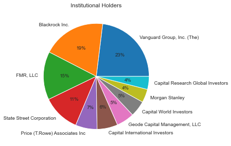

##### 3.2 Quarterly Earning.

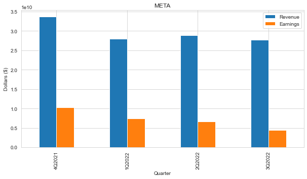